# ⚽⚽⚽ World Cup Winner Prediction! ⚽⚽⚽

## Unfortunately, I started working on this project on the last day of the group stage, so we all know who will advance from their groups. The last thing that we can do is to simulate the knockout stage with teams that advanced. Let's do that

```python
def simulateKnockoutStage(teams):
  _, winner1eight1 = simulateMatch_v4(teams[0], teams[1])
  _, winner1eight2 = simulateMatch_v4(teams[2], teams[3])
  _, winner1eight3 = simulateMatch_v4(teams[4], teams[5])
  _, winner1eight4 = simulateMatch_v4(teams[6], teams[7])
  _, winner1eight5 = simulateMatch_v4(teams[8], teams[9])
  _, winner1eight6 = simulateMatch_v4(teams[10], teams[11])
  _, winner1eight7 = simulateMatch_v4(teams[12], teams[13])
  _, winner1eight8 = simulateMatch_v4(teams[14], teams[15])

  _, winnerQuarter1 = simulateMatch_v4(winner1eight1, winner1eight2)
  _, winnerQuarter2 = simulateMatch_v4(winner1eight3, winner1eight4)
  _, winnerQuarter3 = simulateMatch_v4(winner1eight5, winner1eight6)
  _, winnerQuarter4 = simulateMatch_v4(winner1eight7, winner1eight8)

  _, winnerSemiFinal1 = simulateMatch_v4(winnerQuarter1, winnerQuarter2)
  _, winnerSemiFinal2 = simulateMatch_v4(winnerQuarter3, winnerQuarter4)

  _, winnerFinal = simulateMatch_v4(winnerSemiFinal1, winnerSemiFinal2)

  return winnerFinal
```

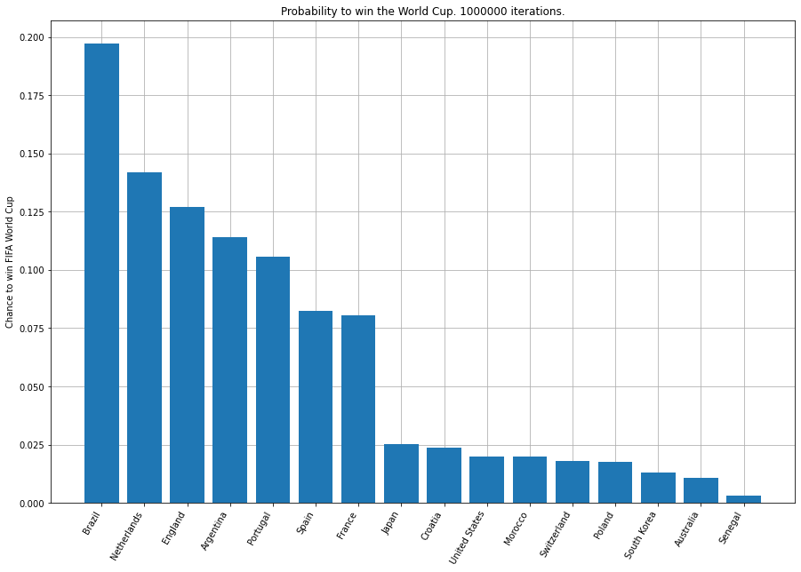

```python
advancedTeams = ['Netherlands', 'United States', 'Argentina', 'Australia', 'Japan', 'Croatia', 'Brazil', 'South Korea', 'France', 'Poland', 'England', 'Senegal', 'Morocco', 'Spain', 'Portugal', 'Switzerland']
winners = {}
for country in np.reshape(advancedTeams, [16]):
  winners[country] = 0

iterations = 1000000
for _ in range(iterations):
  winner = simulateKnockoutStage(advancedTeams)
  winners[winner] += 1

winners = dict(sorted(winners.items(), key=lambda x: x[1], reverse=True))

for key in winners.keys():
  winners[key] /= iterations
plt.figure(figsize=(15, 10))
plt.grid(zorder=0)
plt.xticks(rotation=60, ha='right')
plt.grid
plt.ylabel('Chance to win FIFA World Cup')
plt.title(f'Probability to win the World Cup. {iterations} iterations.')
plt.bar(winners.keys(), winners.values(), zorder=3);
```

## No surprise it's still Brazil at about 20% of chance to win

## Last thing we can do is to simulate a single match between France and Poland. Let's do that..

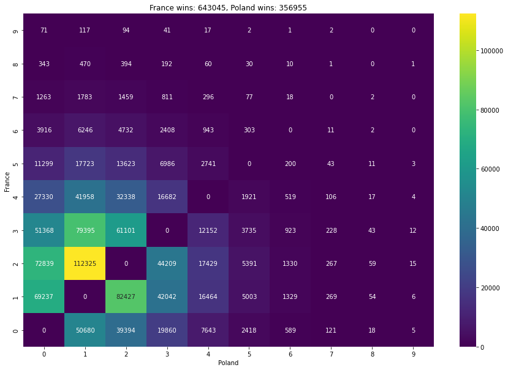

```python
def simulateMatchHeatmapFinal(teamA, teamB, iterations=1000000):
  winners = {teamA: 0,
             teamB: 0}
  resultsTeamA = []
  resultsTeamB = []
  for _ in range(iterations):
    result, winner = simulateMatch_v4(teamA, teamB, canBeDraw=False)
    winners[winner] += 1
    resultsTeamA.append(result[0])
    resultsTeamB.append(result[1])
  plt.figure(figsize=(15, 10))
  plt.title(f'{teamA} wins: {winners[teamA]}, {teamB} wins: {winners[teamB]}')
  ax = sns.heatmap(confusion_matrix(resultsTeamA, resultsTeamB), annot=True, fmt='g', cmap='viridis')
  ax.invert_yaxis()
  plt.ylabel(teamA)
  plt.xlabel(teamB)

simulateMatchHeatmapFinal('France', 'Poland', 1000000)
```

## Results says clearly that the French team is stronger (64% of winning). The most probable result is 2-1 for France. Results that occured more than 51k times (5,1% chance to occur) are 1-0, 2-0, 3-0, 2-1, 3-1, 3-2 for France and 1-2 for Poland.

## So we wish our underdog to score as many goals as possible today!